# Model Comparison: Coronary Heart Disease Risk Prediction

```r
#Load libraries and set seed
library(table1)
library(DescTools)
library(dplyr)
library(ggplot2)
library(rpart)
library(rpart.plot)
library(ROCit)
library(ranger)
library(caret)
library(Matrix)
library(xgboost)
library(tibble)
library(knitr)
library(kableExtra)
set.seed(12)

# Create helper functions

## Define function to identify and change categorical variables into factors ---
fatorize_catagorical<-function(df) {

  numerical_variables<-c()
  categorical_variables<-c()

  #Identify numerical variables and categorical variables
  for (col in colnames(df)){
    if(nrow(unique(df[col]))>20){
      numerical_variables<-c(numerical_variables, col)
    } else if (nrow(unique(df[col]))<=20){
      categorical_variables<-c(categorical_variables, col)
    }
  }

  # Change categorical variables into factors
  df[categorical_variables] <- lapply(df[categorical_variables], as.factor)

  # Code labels of factors
  levels(df[["chd"]])<-c("No", "Yes")

  levels(df[["sex"]])<-c("Male", "Female")
  levels(df[["race"]])<-c("White - Non-Hispanic", "Black - Non-Hispanic", "Hispanic",
                          "Other race only, Non-Hispanic", "Multiracial, Non-Hispanic")
  age_gp_label<-c("18-24", "25-29", "30-34", "35-39", "40-44", "45-49",
                  "50-54", "55-59", "60-64", "65-69", "70-74", "75-79", "80 or older")
  levels(df[["age5y"]])<-age_gp_label
  levels(df[["ever_married"]])<-c("No", "Yes")

  levels(df[["education"]])<-c("Did not graduate high school",
                               "Graduated high school",
                               "Attended college or technical school",
                               "Graduated from college or technical school")
  levels(df[["income"]])<-c("Less than $15,000", "$15,000 to less than $25,000",
                            "$25,000 to less than $35,000", "$35,000 to less than $50,000",
                            "$50,000 or more")
  levels(df[["employment"]])<-c("Employed for wages", "Self-employed",
                                "Out of work for 1 year or more",
                                "Out of work for less than 1 year",
                                "A homemaker", "A student", "Retired")

  levels(df[["diabetes"]])<-c("No", "Yes")
  levels(df[["hypertension"]])<-c("No", "Yes")

  levels(df[["smoke"]])<-c("Never smoked", "Current smoker", "Former smoker")
  levels(df[["vegetable"]])<-c("Consumed less than one time per day", "Consumed one or more times per day")
  levels(df[["fruit"]])<-c("Consumed less than one time per day", "Consumed one or more times per day")
  levels(df[["exercise"]])<-c("No", "Yes")

  # Return formatted dataframe
  return(df)
}



## Define function that changes `age5g` into 3 categories
categorize_age3g <- function(age_range) {
  if (age_range %in% c("18-24", "25-29", "30-34", "35-39", "40-44")) {
    return("18-44")
  } else if (age_range %in% c("45-49", "50-54", "55-59", "60-64")) {
    return("45-65")
  } else if (age_range %in% c("65-69", "70-74", "75-79", "80 or older")) {
    return("65 or older")
  } else {
    return("Invalid age range")
  }
}



## Define function that adds model AUC results to a data frame
get_AUC<-function(model_roc){
  model_AUC<-ciAUC(model_roc)
  results<-c("AUC" = model_AUC[["AUC"]],
             "Lower.CI" = model_AUC[["lower"]],
             "Upper.CI" = model_AUC[["upper"]])
  return(results)
}


## Define function that graphs variable importance
  # Input = tibble containing `Feature` and `Importance` columns and graph

graph_var_importance<-function(df, fig_number = 1 , model_name = "Model"){
  # Reorder the factor levels of variables based on importance
  df$Feature <- factor(df$Feature,
                       levels=df$Feature[order(df$Importance, decreasing = FALSE)])

  # Create plot of variable importance
  title = paste0("Variable Importance with ", model_name)
  caption = paste0("Fig. ", fig_number, ". Importance of variables in predicting the occurrence of CHD with a ", model_name, ".")
  ggplot(df, aes(x = Feature, y = Importance)) +
    geom_pointrange(aes(ymin = 0, ymax = Importance), color = "cadetblue", size = .3) +
    theme_minimal() +
    coord_flip() +
    labs(x = "", y = "", title = title, caption = caption)
}

## Define function to calculate metrics
calculate_metrics <- function(prediction_score, actual_labels) {

  predictions <- ifelse(prediction_score > 0.5, 1, 0)

  # Calculate confusion matrix
  confusion <- table(Actual = actual_labels, Predicted = predictions)

  # Calculate true positives, true negatives, false positives, and false negatives
  TP <- confusion[2, 2]
  TN <- confusion[1, 1]
  FP <- confusion[1, 2]
  FN <- confusion[2, 1]


  # Calculate metrics
  accuracy <- (TP+TN) / (TP +TN + FN + FP)
  precision <- TP / (TP + FP)
  recall <- TP / (TP + FN)
  f1_score <- 2 * precision * recall / (precision + recall)

  # Return metrics
  metrics <- c(Accuracy = accuracy, Precision = precision, Recall = recall, F1_Score = f1_score)
  return(metrics)
}


## Define function to format table output of performance metrics and AUROC

format_metricstable <- function(table) {
  table %>%
    mutate(
      Accuracy = round(Accuracy, 4),
      Precision = round(Precision, 4),
      Recall = round(Recall, 4),
      F1_Score = round(F1_Score, 4),
      AUC = glue::glue("{round(AUC,4)} [{round(Lower.CI,4)}, {round(Upper.CI,4)}]")
    ) %>%
    dplyr::select(Model,
                  Accuracy,
                  Precision,
                  Recall,
                  `F1 Score` = F1_Score,
                  `AUC [lci, uci]` = AUC)
}
```

# Biostat 216 Final Project

## Introduction

Coronary heart disease (CHD) is a common health risk for men above the age of 45 and for women above age of 55. It is often caused by plaque build-up in blood vessels, obstructing blood flow, preventing sufficient oxygen from reaching the heart.[1] Extensive analysis in cohort studies such as the Framingham study identified risk factors of CHD include age progression, family history, cholesterol profile, hypertension, diabetes, lack of exercise and smoking status.[2] Although many prediction models were built to estimate CHD risk. Many of them included clinical data such as LDL-C count, HDL-C counts, systolic blood pressure, and diastolic blood pressure. [3]

## Goal

This study aims to create a cost-effective and personalized method for predicting coronary heart disease (CHD) risk using non-clinical data. Instead of relying solely on clinical metrics like cholesterol levels or blood pressure, the model will incorporate demographic, socioeconomic, and behavioral factors to make CHD risk assessment more accessible.

## Methods

**1. Data Source**

- Behavioral Risk Factor Surveillance System (BFRSS) is a nation-wide survey conducted through telephone calls into households in the United States. [4, 5]
- Survey data from 2015 was downloaded from Kaggle[4] and processed using Python for data cleaning.

**2. Variables**

- **Outcome**: the diagnosis of angina or coronary heart disease (CHD).
- **Predictors**: 15 predictors were selected
  - *Demographic variables*: sex, race, age, and marital status (ever married).
  - *Socioeconomic status variables*: education, income, and employment.
  - *Health-related factors*: diabetes, hypertension, and body mass index (BMI).
  - *Behavioral variables*: smoking, vegetable consumption, fruit consumption, binge drinking, and exercise.

**3. Inclusion / Exclusion**

- **Inclusion:** Anyone with a CHD diagnosis result at 2015.
- **Exclusions:** Individuals with hypertension only during pregnancy or those classified as borderline high or pre-hypertensive were excluded.

**4. Data Balancing**

- The data showed an imbalance in CHD cases and controls after data cleaning: 140,466 controls vs. 5,915 cases.
- To balance the classes, a random sample of 5,915 individuals without CHD was selected, creating a subsample of 11,830 individuals.
- **Data split**: 3:1:1 ratio for model training, validation, and testing

**5. Model Selection & Hyperparameter Tuning**

**6. Feature Importance**

- For the **simple regression tree** and **random forest**, feature importance was assessed using the *Gini index*.
- For **XGBoost**, feature importance was measured using the *gain criterion*.

```r
# Load data
data<-read.csv("cleaned_data.csv")
dataN<-data[sample(seq(nrow(data))),] #shuffle data

# Format categorical variables
  # keep dataN as numerical variable
dataC<-fatorize_catagorical(dataN)


dataEDA<-dataC

dataEDA$age3g<-sapply(dataEDA$age5y, categorize_age3g)

names(dataEDA)<-c("CHD", "Sex", "Race", "Age in 5-Year Group",
                  "Ever Married", "Education", "Income",
                  "Employment Status","Diabetes", "Hypertension", "BMI",
                  "Smoking Status", "Vegetable consumption",
                  "Fruit consumption",
                  "Times of binge drinking in past 30 days", "Exercise",
                  "Age Group")
```

## Results

### Demographics

```r
captiont1 <- "Table 1 - Socio-demographic characteristics of subsampled BRFSS 2015 participants"
footnote <- ""
table1(~ Sex + Race + `Age Group` + `Ever Married` + `Education` + `Income` | CHD, data = dataEDA, caption = captiont1, footnote = footnote)
```

Table 1 - Socio-demographic characteristics of subsampled BRFSS 2015 participants

|  | No (N=5915) | Yes (N=5915) | Overall (N=11830) |
| --- | --- | --- | --- |
| Sex |  |  |  |
| Male | 2994 (50.6%) | 4225 (71.4%) | 7219 (61.0%) |
| Female | 2921 (49.4%) | 1690 (28.6%) | 4611 (39.0%) |
| Race |  |  |  |
| White - Non-Hispanic | 4934 (83.4%) | 5334 (90.2%) | 10268 (86.8%) |
| Black - Non-Hispanic | 309 (5.2%) | 206 (3.5%) | 515 (4.4%) |
| Hispanic | 365 (6.2%) | 175 (3.0%) | 540 (4.6%) |
| Other race only, Non-Hispanic | 208 (3.5%) | 125 (2.1%) | 333 (2.8%) |
| Multiracial, Non-Hispanic | 99 (1.7%) | 75 (1.3%) | 174 (1.5%) |
| Age Group |  |  |  |
| 18-44 | 1885 (31.9%) | 164 (2.8%) | 2049 (17.3%) |
| 45-65 | 2460 (41.6%) | 1613 (27.3%) | 4073 (34.4%) |
| 65 or older | 1570 (26.5%) | 4138 (70.0%) | 5708 (48.3%) |
| Ever Married |  |  |  |
| No | 1150 (19.4%) | 397 (6.7%) | 1547 (13.1%) |
| Yes | 4765 (80.6%) | 5518 (93.3%) | 10283 (86.9%) |
| Education |  |  |  |
| Did not graduate high school | 194 (3.3%) | 227 (3.8%) | 421 (3.6%) |
| Graduated high school | 1201 (20.3%) | 1363 (23.0%) | 2564 (21.7%) |
| Attended college or technical school | 1562 (26.4%) | 1599 (27.0%) | 3161 (26.7%) |
| Graduated from college or technical school | 2958 (50.0%) | 2726 (46.1%) | 5684 (48.0%) |
| Income |  |  |  |
| Less than $15,000 | 244 (4.1%) | 268 (4.5%) | 512 (4.3%) |
| $15,000 to less than $25,000 | 573 (9.7%) | 720 (12.2%) | 1293 (10.9%) |
| $25,000 to less than $35,000 | 492 (8.3%) | 694 (11.7%) | 1186 (10.0%) |
| $35,000 to less than $50,000 | 839 (14.2%) | 988 (16.7%) | 1827 (15.4%) |
| $50,000 or more | 3767 (63.7%) | 3245 (54.9%) | 7012 (59.3%) |

### Model Training

```r
##code block format{r, fig.show='hide'}


# MODEL TRAINING

# Data preparation ----
# Split training and testing data with caret
split_train_test <- createDataPartition(y = dataN$chd, p = 0.8, list = FALSE)
split_train_val <- createDataPartition(y = dataN$chd[split_train_test], p = 0.75, list = FALSE)

# Record index vectors for training, testing, validation datasets
total_idx<-seq(nrow(dataN))
test_idx <- total_idx[!total_idx %in%  split_train_test]
train_idx<-split_train_test[split_train_val]
val_idx<-split_train_test[-split_train_val]


glue::glue("
-----  Data Split  -----
Total number of samples: {length(total_idx)}
Number of training samples: {length(train_idx)}
Number of validation samples: {length(val_idx)}
Number of testing samples: {length(test_idx)}
           ")
```

```
## -----  Data Split  -----
## Total number of samples: 11830
## Number of training samples: 7098
## Number of validation samples: 2366
## Number of testing samples: 2366
```

```r
# Simple Regression Tree ----
## Fit first simple regression tree
data_train <- dataC[train_idx, ]
data_val <- dataC[val_idx, ]

chd_rpart <- rpart(chd~., method="class", data=data_train, cp=0.0001)
plotcp(chd_rpart, upper="splits")
```

```r
## code block format{r, fig.show='hide', results=FALSE}

## Prune
  # Select cp for pruning (just below minimum xerror+xstd threshold)
cp_table<-data.frame(chd_rpart$cptable)
threshold<-cp_table$xerror[which.min(cp_table$xerror)]+cp_table$xstd[which.min(cp_table$xerror)]
chd_pruned_rpart <- prune(chd_rpart,
                          cp=cp_table$CP[which.max(cp_table$xerror<threshold)])
glue::glue("
-----   Regression tree: optimal hyperparameters  -----
Cross-Validation Error Threshold: {threshold}
Optimal number of splits: {cp_table$nsplit[which.max(cp_table$xerror<threshold)]}")



# Random forest  ----
data_rf<-dataC
data_train<-data_rf[train_idx,]
data_val<-data_rf[val_idx,]


## Set up the cross-validation scheme for hyperparameter tuning
train_control <- trainControl(method = "cv",
                              number = 3,
                              search = "grid",
                              classProbs = T)
paramDF <- expand.grid(mtry=1:14,
                       splitrule = "gini",
                       min.node.size = 1)

## Perform the grid search using caret
chd_rf_cv <- train(chd~., data = data_train,
                   method = "ranger",
                   trControl = train_control,
                   tuneGrid = paramDF,
                   importance = "impurity",
                   metric = "AUC")

## Use best parameter values to train new random forest get feature importance
chd_rf <- ranger(chd~., data = data_train,
                 num.trees = chd_rf_cv$finalModel$num.trees,
                 mtry=chd_rf_cv$finalModel$mtry,
                 importance = chd_rf_cv$finalModel$importance.mode,
                 splitrule = chd_rf_cv$finalModel$splitrule,
                 min.node.size = chd_rf_cv$finalModel$min.node.size,
                 probability = TRUE)

## Print final model hyperparameters
glue::glue("
-----   Random forest: optimal hyperparameters  -----
Number of trees: {chd_rf_cv$finalModel$num.trees}
Number of variables to split at each node: {chd_rf_cv$finalModel$mtry}
Minimal node size: {chd_rf_cv$finalModel$min.node.size}
           ")


# XGboost ----

  # Prepare data
xgbTrain_x <- sparse.model.matrix(chd ~ . - 1, data = dataC[train_idx, ], sep=": ")
xgbVal_x <- sparse.model.matrix(chd ~ . - 1, data = dataC[val_idx, ], sep=": ")
output_vector <- ifelse(dataC$chd=="Yes", 1, 0)
  # Format inputs for xgboost
xgbTrain <- xgb.DMatrix(xgbTrain_x, label = output_vector[train_idx])
xgbVal <- xgb.DMatrix(xgbVal_x, label = output_vector[val_idx])


# The set param df and train to find best hyperparameters
paramDF <- expand.grid(
  eta = c(0.05, 0.1, 0.5),
  gamma = c(0,100),
  max_depth = c(2L, 5L, 10L),
  nrounds = c(100, 500, 1000))

best_params <- NULL
best_metric <- -Inf

# Iterate over each combination of parameters
for (i in 1:nrow(paramDF)) {
  params <- paramDF[i, ]

  # Perform cross-validation with current parameters
  cv_result <- xgb.cv(data = xgbTrain,  # Provide your data here
                      nfold = 3,       # Number of folds for cross-validation
                      params = list(objective = "binary:logistic",  # Objective function
                                    eval_metric = "auc",  # Evaluation metric
                                    eta = params$eta,
                                    gamma = params$gamma,
                                    max_depth = params$max_depth),
                      nrounds = params$nrounds,   # Number of boosting rounds
                      early_stopping_rounds = 20,  # Early stopping rounds
                      verbose = FALSE)  # Suppress verbose output

  # Check if current parameters yield better results
  mean_auc <- tail(cv_result$evaluation_log$test_auc_mean, 1)
  if (mean_auc > best_metric) {
    best_metric <- mean_auc
    best_params <- params
  }
}

# Retrain best model with validation data
watchlist <- list(train = xgbTrain, eval = xgbVal)
chd_xgb <- xgb.train(xgbTrain, nrounds = best_params$nrounds,
                     params=list(eta=best_params$eta,
                                 gamma=best_params$gamma,
                                 max_depth=best_params$max_depth,
                                 objective="binary:logistic",
                                 eval_metric = "auc"),
                     verbose = 0,
                     early_stopping_rounds = 20,
                     watchlist=watchlist)

ggplot(chd_xgb$evaluation_log, aes(x = iter)) +
  geom_line(aes(y = train_auc, color = "Train")) +
  geom_line(aes(y = eval_auc, color = "Validation" )) +
  scale_color_manual(name = "Data", values = c("Train" = "red", "Validation" = "blue")) +
  labs(x = "Iterations", y = "AUC") +
  theme_minimal()
```

```r
## Print final model hyperparameters
glue::glue("
-----   XGBoost: optimal hyperparameters  -----
Number of boosting rounds: {best_params$nrounds}
learning rate: {best_params$eta}
gamma (minimum loss reduction): {best_params$gamma}
maximum depth of a tree: {best_params$max_depth}")
```

[output not shown]

### Model Comparison

We compared the performance of simple regression tree, random forest, and XGBoost on the validation dataset. Table 2 and Table 3 shows performance evaluation of accuracy , precision, recall, F1 score, and AUROC. The metrics given the most importance is recall as we would like to be able to detect risk of CHD to implement any early mediation. XGBoost was the best performing model with highest accuracy, recall, F1 score, and AUROC.

```r
## Metrics Table ----
# Get prediction scores
pruned_rpart_predscore<-predict(chd_pruned_rpart, newdata=data_val, type="prob")[,2]

pred_rf<-predict(chd_rf, data=data_val, type="response")
chd_rf_predscore<-pred_rf$predictions[,2]

chd_xgb_predscore<-predict(chd_xgb, newdata=xgbVal, type="response")

# Calculate ROC
pruned_rpart_roc<-rocit(score=pruned_rpart_predscore, class=data_val$chd)  #regression tree
chd_rf_roc<-rocit(score=chd_rf_predscore, class=data_val$chd)  # random forest
chd_xgb_roc<-rocit(score=chd_xgb_predscore, class=data_val$chd)  # XGBoost


# Get metrics and AUROC
bind_rows(
  c(calculate_metrics(pruned_rpart_predscore, data_val$chd), get_AUC(pruned_rpart_roc)),
  c(calculate_metrics(chd_rf_predscore, data_val$chd), get_AUC(chd_rf_roc)),
  c(calculate_metrics(chd_xgb_predscore, data_val$chd), get_AUC(chd_xgb_roc))
  ) %>%
  # Format
  mutate(Model = c("Simple Regression Tree", "Random Forest", "XGBoost")) %>%
  format_metricstable() %>%
  # Print metrics table
  kable(caption = "Table 2: Validation Set Performance Metrics and AUROC") %>%
  kable_styling(full_width = F, font_size = 14)
```

Table 2: Validation Set Performance Metrics and AUROC

| Model | Accuracy | Precision | Recall | F1 Score | AUC [lci, uci] |
| --- | --- | --- | --- | --- | --- |
| Simple Regression Tree | 0.7688 | 0.7405 | 0.8276 | 0.7816 | 0.8146 [0.7974, 0.8319] |
| Random Forest | 0.7675 | 0.7463 | 0.8107 | 0.7771 | 0.8327 [0.8163, 0.8492] |
| XGBoost | 0.7735 | 0.7456 | 0.8301 | 0.7856 | 0.8414 [0.8253, 0.8574] |

### Model Selection and Testing

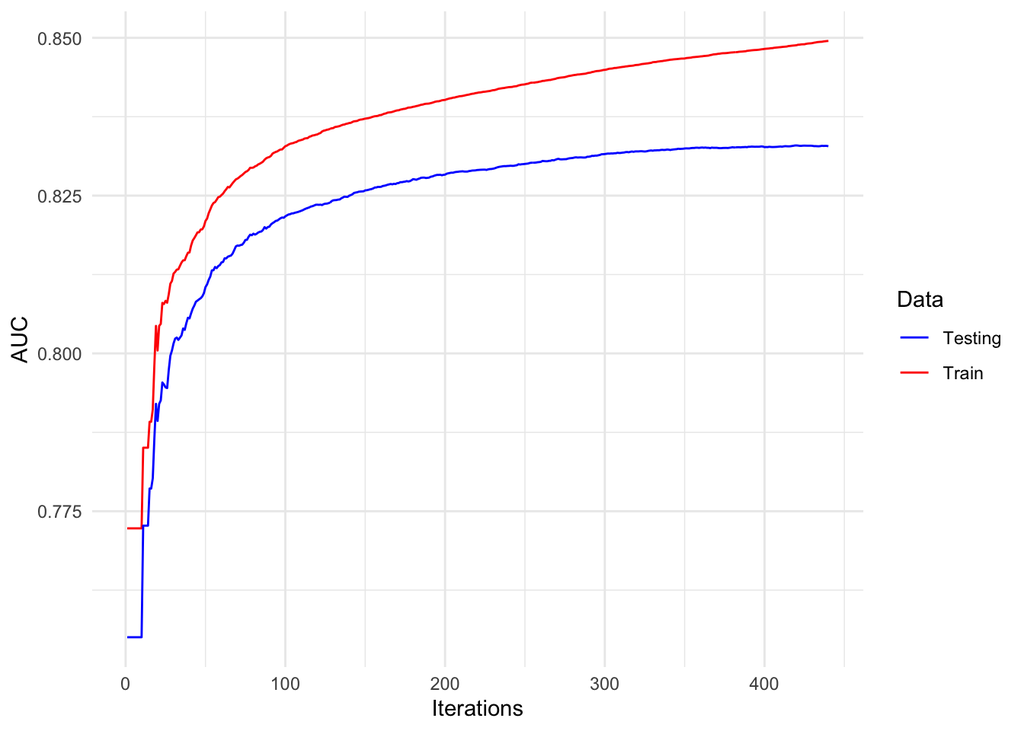

```r
  ## Prepare data
xgbfTrain_x <- sparse.model.matrix(chd ~ . - 1, data = dataC[c(train_idx,val_idx), ], sep=": ")
xgbTest_x <- sparse.model.matrix(chd ~ . - 1, data = dataC[test_idx, ], sep=": ")
output_vector <- ifelse(dataC$chd=="Yes", 1, 0)
  ## Format inputs for xgboost
xgbfTrain <- xgb.DMatrix(xgbfTrain_x, label = output_vector[c(train_idx,val_idx)])
xgbTest <- xgb.DMatrix(xgbTest_x, label = output_vector[test_idx])

  ## Re-train on training +validation set
  ## Test on final heldout test set
watchlist <- list(train = xgbTrain, eval = xgbTest)
final_model <- xgb.train(xgbTrain, nrounds = best_params$nrounds,
                         params=list(eta=best_params$eta,
                                     gamma=best_params$gamma,
                                  max_depth=best_params$max_depth,
                                  objective="binary:logistic",
                                  eval_metric = "auc"),
                         verbose = 0,
                         early_stopping_rounds = 20,
                         watchlist=watchlist)
ggplot(final_model$evaluation_log, aes(x = iter)) +
  geom_line(aes(y = train_auc, color = "Train")) +
  geom_line(aes(y = eval_auc, color = "Testing" )) +
  scale_color_manual(name = "Data", values = c("Train" = "red", "Testing" = "blue")) +
  labs(x = "Iterations", y = "AUC") +
  theme_minimal()
```

Testing results showed that the final XGBoost model had slightly lower recall at 0.795.

```r
# Get prediction scores
final_model_predscore<-predict(final_model, newdata=xgbTest, type="response")
final_model_roc<-rocit(score=final_model_predscore, class=dataC[test_idx, "chd"])

# Get metrics
bind_rows(c(calculate_metrics(final_model_predscore, dataC[test_idx, "chd"]),
        get_AUC(final_model_roc))) %>%
  # Format
  mutate(Model = c("Final XGBoost Model")) %>%
  format_metricstable() %>%
  # Print table
  kable(caption = "Table 3: Final Model Test Set Performance Metrics and AUROC") %>%
  kable_styling(full_width = F, font_size = 14)
```

Table 3: Final Model Test Set Performance Metrics and AUROC

| Model | Accuracy | Precision | Recall | F1 Score | AUC [lci, uci] |
| --- | --- | --- | --- | --- | --- |
| Final XGBoost Model | 0.754 | 0.7346 | 0.7954 | 0.7638 | 0.8329 [0.8165, 0.8494] |

[figure not shown]

```r
# Plot AUC curves
ggplot()+
  geom_abline(slope=1,intercept=0, color = "grey", linetype = "dashed")+

  geom_line(data=data.frame("TPR"=pruned_rpart_roc$TPR,"FPR"=pruned_rpart_roc$FPR) , aes(x=FPR, y=TPR, color = "Simple Regression Tree")) +
  geom_line(data=data.frame("TPR"=chd_rf_roc$TPR,"FPR"=chd_rf_roc$FPR) , aes(x=FPR, y=TPR,  color = "Random Forest")) +
  geom_line(data=data.frame("TPR"=chd_xgb_roc$TPR,"FPR"=chd_xgb_roc$FPR) , aes(x=FPR, y=TPR,  color = "XGBoost")) +
  geom_line(data=data.frame("TPR"=final_model_roc$TPR,"FPR"=final_model_roc$FPR) , aes(x=FPR, y=TPR,  color = "Final Model - XGBoost")) +

  labs(title = "ROC Curves", x = "1-Specificity (FPR)",
       y = "Sensitivity (TPR)", color = "Model",
       caption = "Fig. 1: ROC curve for Simple Regression Tree, Random Forest, and XGBoost Models") +
  scale_color_hue(labels = c("Simple Regression Tree", "Random Forest", "XGBoost", "Final Model - XGBoost"))
```

### Feature importance analysis

The most importance features were preserved across models.

- Fig. 2 and 3 shows that **5-year age groups** is the most important feature in simple regression tree and random forest.
- XGBoost models show some agreement with age as one of the most important features. As shown in Fig. 4 and 5, among the top 15 important features of the XGBoost models, different categories of age appears in high frequency. Other variables that were also highly important in different models include hypertension and employment.

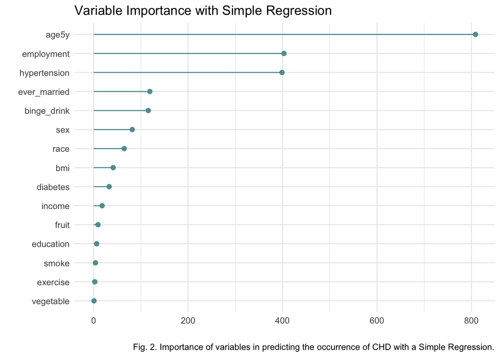

```r
# Generate variable importance graphs for each model

# Simple Regression
  # Create tibble to hold variable importance
pruned_rpart_vi <-chd_pruned_rpart$variable.importance %>% data.frame() %>%
                        rownames_to_column(var = "Feature") %>% rename(Importance = '.')
  # Create plot of variable importance
graph_var_importance(pruned_rpart_vi, 2, "Simple Regression")
```

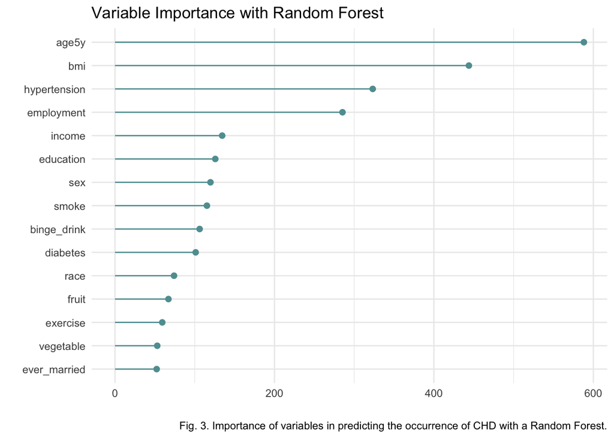

```r
# Random Forest
  # Create tibble to hold variable importance
chd_rf_vi <-chd_rf$variable.importance %>% data.frame() %>%
                        rownames_to_column(var = "Feature") %>% rename(Importance = '.')
  # Create plot of variable importance
graph_var_importance(chd_rf_vi, 3, "Random Forest")
```

[figure not shown]

```r
# XGBoost
  # Create tibble to hold variable importance
xgb_vi_gain <- xgb.importance(feature_names = colnames(xgbTrain_x), model = chd_xgb)[,c(1,2)]
names(xgb_vi_gain)<-c("Feature", "Importance")
  # Create plot of variable importance
graph_var_importance(xgb_vi_gain[1:15,], 4, "XGBoost")
```

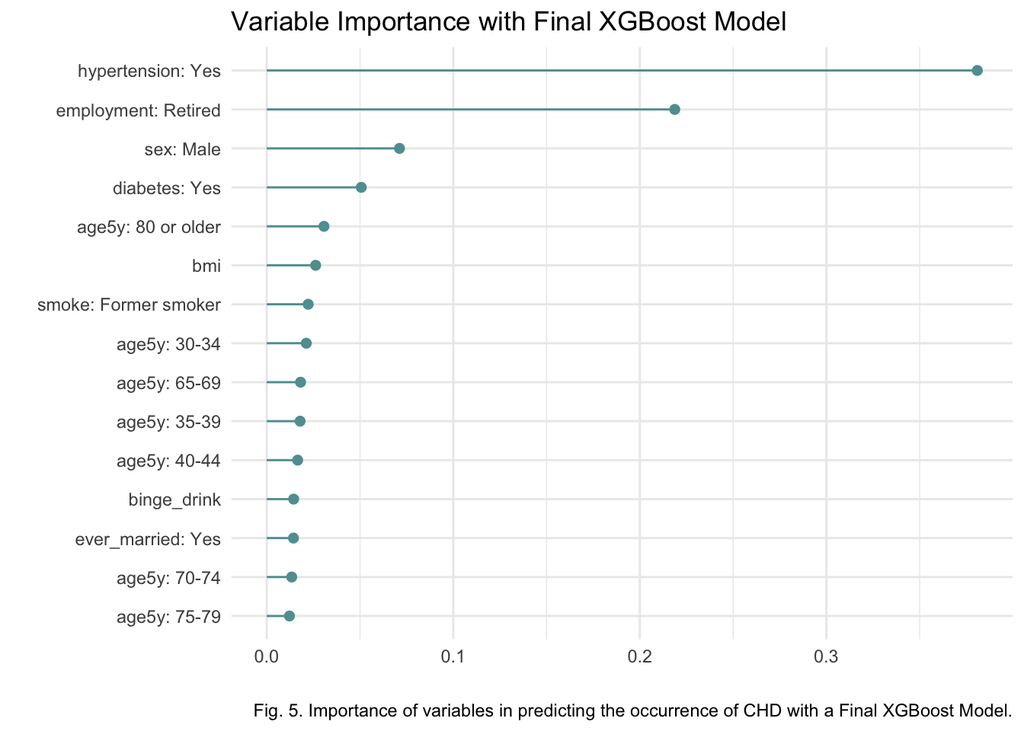

```r
# Final XGBoost Model
  # Create tibble to hold variable importance
final_vi <- xgb.importance(feature_names = colnames(xgbTrain_x), model = final_model)[,c(1,2)]
names(final_vi)<-c("Feature", "Importance")
  # Create plot of variable importance
graph_var_importance(final_vi[1:15,], 5, "Final XGBoost Model")
```

## Discussion

In this project, we presented a model that predicts CHD risk using questionnaire data. We fit the final XGBoost model and found the final model to have ~75.4% accuracy, 73.5 % precision, 79.5% recall and 76.3% F1-score. We also found that among all predictors, age group, hypertension, and employment seemed to be the most important variables in all models.

**Limitations:**

- The analysis of AUROC may not be applicable in random forests because adjusting the decision “threshold” in a random forest does not make sense as it use results of classification from different trees to predict outcome. However, AUROC prediction was enabled though using prediction for out of bag data.
- Comparing feature importance in XGBoost models to feature importance from regression tree or random forest is difficult because of the data format required by XGBoost model. XGBoost model requires categorical variables to be one-hot encoded into binary variables for each level in the categorical variable, distributing the importance of the original categorical variable among the binary variables created from it. An example of this from our models is the categorical variable of 5-year age group `age5y`. It may also have caused the inflated importance values for the binary variables representing rare categories such as age 80 or older, as they may be associated with high gains due to their sparsity.
- Due to the limitation of the of the survey, we were not able to include other commonly known risk factors such as continuous age variable or family history. Since, 5-year age group `age5y` was found to be a strong predictor of CHD risk, it may be desirable to distinguish other predictors within each age group by regrouping age categories and including age as a continuous predictor.

**Strengths:**

- All models were able to predict CHD risk with higher recall and accuracy than random guess.
- XGBoost model correctly identified 79.5% of CHD cases.
- Samples are representative of a large population.

## References

[1] Coronary Heart Disease - Causes and Risk Factors | NHLBI, NIH. NHLBI, NIH. https://www.nhlbi.nih.gov/health/coronary-heart-disease/causes.

[2] Grundy, S. M., Balady, G. J., Criqui, M. H., Fletcher, G., Greenland, P., Hiratzka, L. F., Houston-Miller, N., Kris-Etherton, P., Krumholz, H. M., LaRosa, J., Ockene, I. S., Pearson, T. A., Reed, J., Washington, R., & Smith, S. C. (1998). Primary Prevention of Coronary Heart Disease: Guidance From Framingham. Circulation, 97(18), 1876–1887. https://doi.org/10.1161/01.CIR.97.18.1876

[3] Wilson, P. W. F., D’Agostino, R. B., Levy, D., Belanger, A. M., Silbershatz, H., & Kannel, W. B. (1998). Prediction of Coronary Heart Disease Using Risk Factor Categories. Circulation, 97(18), 1837–1847. https://doi.org/10.1161/01.CIR.97.18.1837

[4] Centers for Disease Control and Prevention. (2017, August 24). Behavioral risk factor surveillance system. Kaggle. https://www.kaggle.com/datasets/cdc/behavioral-risk-factor-surveillance-system

[5] National Center for Chronic Disease Prevention and Health Promotion, Division of Population Health. (2014, May 16). About BRFSS. Centers for Disease Control and Prevention. https://www.cdc.gov/brfss/about/index.htm